# ECS 171 Discussion 1

`Date`: Sep 27, 2022

`TA`: Dechen Gao (dcgao@ucdavis.edu)

The goal of our discussion:

- Coding of ML algorithms related to homeworks and lectures
- This week: how to set up environment for your homeworks
- Next week: linear regression

## Outlines

- What is Jupyter?
- Why we need Jupyter?
- Installation: pip & conda
- Colab & Kaggle usage
- Notebook demos
- Export your notebooks

## Jupyter Notebook

### Pros & Cons

Interactive (Jupyter) vs. non-interactive.

1. Pros
   - Easy debugging and data exploration.
   - Rich visualization and presentation.
2. Cons
   - Bad version control.
   - Not modular.

### Use Jupyter Locally

- **Installation**
  - pip install ([docs](https://jupyter.org/install))
  - conda ([docs](https://conda.io/projects/conda/en/latest/user-guide/install/index.html))
- **Configuration (Optional)**
  - Generate and modify configuration files, or use flags when calling Jupyter
    - e.g., `--notebook-dir`, where to locate your root directory
    - e.g., `--port`, specify a port number for Jupyter server
- **Client**
  - `VS Code`: with Jupyter extension that pulls up Jupyter automatically
  - `Web browser`: you need to pull up Jupyter manually

### Use Jupyter Remotely

#### Remote options

- [Colab](https://colab.research.google.com/)
  - Web browser is all you need to access Notebook.
  - File system is a different (talk about this later).
  - CPU/GPU and RAM limited.
- [Kagale](https://www.kaggle.com/)
  - A competition platform that provides notebook/algorithm resources, datasets.
  - Can access Kaggle datasets easily or you can upload and construct your own.
- SSH
  - expose a Jupyter port on server that can be accessed via your SSH client.
  - One option when you need better performance.

#### Colab File System

Here are [file access demos](https://colab.research.google.com/notebooks/io.ipynb) and our [discussion demo](https://colab.research.google.com/drive/1M4rjr5N_q7x5wFMBge0CVr2FRy9v7cRw?usp=sharing).

By default you only have temporary file access during each session, and therefore you can only upload again when the session restarts.

However, you can mount Google Drive and upload dataset and Python modules to Google Drive.

```
# Mount Google Drive
from google.colab import drive
drive.mount('/content/gdrive')
# Optional. Change root directory. Use !pwd to verify
import os
os.chdir("/content/gdrive/My Drive/Colab Notebooks/")
# Optional. Append to system paths for interpreter to search for modules
import sys
sys.path.append('/content/gdrive/')
```

#### Kaggle Demo

- Explore public datasets and manage your own [Kaggle Datasets](https://www.kaggle.com/datasets)
- Access datasets in your notebook

### Homework Submission (Tentative)

Upload both your Jupyter source and exported PDFs (recommended for HW1) to Gradescope.

- **Required**: source code `.ipynb`
- **Optional**: exported PDF (extra bonus for HW1) plus sources

Why PDF? We grade on Gradescope where PDFs are well supported. We can view comments, and see where points are deducted in PDFs.

#### Solution 1: Export to PDFs

One line command

```
jupyter nbconvert --execute --to pdf your_notebook.ipynb
```

PDF rendering requires [pandoc](https://pandoc.org/installing.html), nbconvert, and LaTex support.

```
# Install pandoc
choco install pandoc    # For Windows
brew install pandoc     # For MacOS
# Install converting tool
pip install nbconvert   # or conda install
```

#### Solution 2: If PDF is not working

- Use the following commands to convert iPython file to HTML first

```
jupyter nbconvert --execute --to html your_notebook.ipynb
```

Open HTML with browser and "Print" in PDF format.

- For Jupyter Notebook opened in web browser, select from top bar `File` and `Download as` PDF.

**If PDF format is messed up**, please first download HTML and then print HTML to PDF in browser.

## GitHub

### Client

- Git shell
- GUI client, e.g., GitHub Desktop

### Basic Usage

- Create your account and repo
- Syncronize your local code sources with remote Git repo
- Create & merge branches (`git branch`)

## Heading 1

### Heading 2

#### Heading 3

#### Heading 4

I'm **bold text**.

I'm *italicized text*.

> Blockquotes are here!

Hyperlink: [Canvas Page](https://canvas.ucdavis.edu/courses/666488).

```
# Code highlighting
print('Hello, world')
```

Formula:

- $\sum_{x = a}^{b} f(x)$
- $\left(\int_{a}^{b} f(x) \; dx\right)$

### Code Section

```python
print('Hello, world!')
```

```
Hello, world!
```

```python
!echo "Hello, world!"
```

```
"Hello, world!"
```

```python
import pandas as pd
data = pd.read_csv('data.csv')
data
```

|  | cache-misses_1s | node-loads_1s | branch-misses_1s | branch-load-misses_1s | LLC-store-misses_1s | branch-loads_1s | L1-dcache-stores_1s | L1-icache-load-misses_1s | branch-instructions_1s | iTLB-loads_1s | ... | L1-icache-load-misses_5s | branch-instructions_5s | iTLB-loads_5s | iTLB-load-misses_5s | dTLB-store-misses_5s | dTLB-load-misses_5s | dTLB-stores_5s | node-stores_5s | L1-dcache-load-misses_5s | label |
| --- | --- | --- | --- | --- | --- | --- | --- | --- | --- | --- | --- | --- | --- | --- | --- | --- | --- | --- | --- | --- | --- |
| 0 | 37514691 | 2822421 | 10070509 | 10559671 | 4972315 | 875088331 | 661114306 | 57139716 | 825641176 | 1274640 | ... | 869593 | 1966467 | 10449 | 23199 | 2277 | 26126 | 1212879 | 16430 | 261616 | 1 |
| 1 | 49901539 | 3999875 | 15983066 | 15905409 | 7812096 | 897853137 | 756436026 | 73999248 | 983561267 | 1721115 | ... | 923435 | 48598163 | 20217 | 23926 | 9173 | 36467 | 18616934 | 116077 | 5774113 | 1 |
| 2 | 50400281 | 3256093 | 15329054 | 15610305 | 7440166 | 909703981 | 734120225 | 70138841 | 948103570 | 1738119 | ... | 454348 | 1932445 | 8099 | 11133 | 1097 | 16018 | 1322034 | 11231 | 169059 | 1 |
| 3 | 33857600 | 2281202 | 12144856 | 12142687 | 6133250 | 898523534 | 722133401 | 58023478 | 924673885 | 1429445 | ... | 1445012 | 9134928 | 10191 | 14334 | 2200 | 9918 | 5576265 | 21731 | 1755962 | 1 |
| 4 | 48650176 | 3510185 | 16656488 | 16676601 | 6020216 | 938655692 | 790604661 | 69916162 | 1039331799 | 1558873 | ... | 1011623 | 42037945 | 29691 | 32148 | 5706 | 23413 | 25445021 | 119196 | 7101670 | 1 |
| ... | ... | ... | ... | ... | ... | ... | ... | ... | ... | ... | ... | ... | ... | ... | ... | ... | ... | ... | ... | ... | ... |
| 2995 | 30437560 | 2326933 | 12585063 | 12241054 | 5041214 | 961290381 | 807913282 | 50286201 | 1012821501 | 1057812 | ... | 4508220 | 6894462 | 70212 | 98023 | 9604 | 111084 | 5819375 | 78739 | 1210270 | 30 |
| 2996 | 35121159 | 2576033 | 14087715 | 13595659 | 5959816 | 993575253 | 861158899 | 54518991 | 1050605365 | 895227 | ... | 5187666 | 9620870 | 97990 | 117748 | 10511 | 132867 | 9296473 | 74737 | 1528661 | 30 |
| 2997 | 34968122 | 2696992 | 14058112 | 13734181 | 4591435 | 955564749 | 820924827 | 61481334 | 1047588424 | 1282742 | ... | 2892833 | 4103961 | 48325 | 59845 | 5794 | 72812 | 3867988 | 43216 | 728741 | 30 |
| 2998 | 29050123 | 2382281 | 11980752 | 12213550 | 5229134 | 965928905 | 788854210 | 62116174 | 960454788 | 1293510 | ... | 17715975 | 122466994 | 103075 | 249578 | 86510 | 321995 | 100615883 | 1018327 | 11113398 | 30 |
| 2999 | 31203289 | 2482180 | 12597138 | 12576162 | 4960137 | 1000022539 | 835397449 | 53078400 | 1000095628 | 963997 | ... | 4866974 | 6441573 | 78765 | 100181 | 9085 | 115750 | 6439933 | 78603 | 1215627 | 30 |

3000 rows × 81 columns

```python
# Select a few columns
data = data[['cache-misses_1s', 'branch-misses_1s', 'LLC-store-misses_1s', 'branch-instructions_1s', 'iTLB-loads_1s', 'label']]
data
```

|  | cache-misses_1s | branch-misses_1s | LLC-store-misses_1s | branch-instructions_1s | iTLB-loads_1s | label |
| --- | --- | --- | --- | --- | --- | --- |
| 0 | 37514691 | 10070509 | 4972315 | 825641176 | 1274640 | 1 |
| 1 | 49901539 | 15983066 | 7812096 | 983561267 | 1721115 | 1 |
| 2 | 50400281 | 15329054 | 7440166 | 948103570 | 1738119 | 1 |
| 3 | 33857600 | 12144856 | 6133250 | 924673885 | 1429445 | 1 |
| 4 | 48650176 | 16656488 | 6020216 | 1039331799 | 1558873 | 1 |
| ... | ... | ... | ... | ... | ... | ... |
| 2995 | 30437560 | 12585063 | 5041214 | 1012821501 | 1057812 | 30 |
| 2996 | 35121159 | 14087715 | 5959816 | 1050605365 | 895227 | 30 |
| 2997 | 34968122 | 14058112 | 4591435 | 1047588424 | 1282742 | 30 |
| 2998 | 29050123 | 11980752 | 5229134 | 960454788 | 1293510 | 30 |
| 2999 | 31203289 | 12597138 | 4960137 | 1000095628 | 963997 | 30 |

3000 rows × 6 columns

```python
data.shape
```

```
(3000, 6)
```

```python
# What's in data?
data.info()
```

```
<class 'pandas.core.frame.DataFrame'>
RangeIndex: 3000 entries, 0 to 2999
Data columns (total 6 columns):
 #   Column                  Non-Null Count  Dtype
---  ------                  --------------  -----
 0   cache-misses_1s         3000 non-null   int64
 1   branch-misses_1s        3000 non-null   int64
 2   LLC-store-misses_1s     3000 non-null   int64
 3   branch-instructions_1s  3000 non-null   int64
 4   iTLB-loads_1s           3000 non-null   int64
 5   label                   3000 non-null   int64
dtypes: int64(6)
memory usage: 140.8 KB
```

```python
data.describe()
```

|  | cache-misses_1s | branch-misses_1s | LLC-store-misses_1s | branch-instructions_1s | iTLB-loads_1s | label |
| --- | --- | --- | --- | --- | --- | --- |
| count | 3.000000e+03 | 3.000000e+03 | 3.000000e+03 | 3.000000e+03 | 3.000000e+03 | 3000.000000 |
| mean | 3.574264e+07 | 1.320227e+07 | 5.776213e+06 | 9.891446e+08 | 1.098288e+06 | 15.500000 |
| std | 7.392098e+06 | 2.180458e+06 | 1.223957e+06 | 1.098516e+08 | 3.104263e+05 | 8.656884 |
| min | 6.707911e+06 | 5.306539e+06 | 9.561360e+05 | 3.090067e+08 | 2.007580e+05 | 1.000000 |
| 25% | 3.119621e+07 | 1.185055e+07 | 4.980937e+06 | 9.139577e+08 | 8.916890e+05 | 8.000000 |
| 50% | 3.365164e+07 | 1.256955e+07 | 5.609685e+06 | 9.727026e+08 | 1.039418e+06 | 15.500000 |
| 75% | 3.777566e+07 | 1.393846e+07 | 6.375148e+06 | 1.044031e+09 | 1.216392e+06 | 23.000000 |
| max | 6.644830e+07 | 2.228168e+07 | 1.157133e+07 | 1.374149e+09 | 2.516269e+06 | 30.000000 |

```python
import seaborn as sns
from matplotlib import pyplot as plt
# Color style
sns.set_style('whitegrid')
# Set figure size
plt.figure(figsize=(8, 6))
sns.scatterplot(data=data, x='branch-instructions_1s', y='cache-misses_1s')
```

[output not shown]

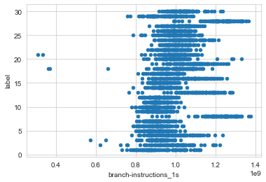

```python
# Or you can use pandas builtin to plot
data.plot.scatter(x='branch-instructions_1s', y='label')
```

```python
# Pearson correlation by default in pandas
corr = data.corr()
# This is an example using pandas built-in visualization
# Determine the background colors with values in cells
corr.style.set_precision(3).background_gradient(cmap='RdBu', vmin=-1, vmax=1)
```

|  | cache-misses_1s | branch-misses_1s | LLC-store-misses_1s | branch-instructions_1s | iTLB-loads_1s | label |
| --- | --- | --- | --- | --- | --- | --- |
| cache-misses_1s | 1.000 | 0.867 | 0.617 | 0.735 | 0.651 | -0.072 |
| branch-misses_1s | 0.867 | 1.000 | 0.688 | 0.818 | 0.732 | 0.124 |
| LLC-store-misses_1s | 0.617 | 0.688 | 1.000 | 0.516 | 0.653 | 0.013 |
| branch-instructions_1s | 0.735 | 0.818 | 0.516 | 1.000 | 0.534 | 0.305 |
| iTLB-loads_1s | 0.651 | 0.732 | 0.653 | 0.534 | 1.000 | 0.086 |
| label | -0.072 | 0.124 | 0.013 | 0.305 | 0.086 | 1.000 |

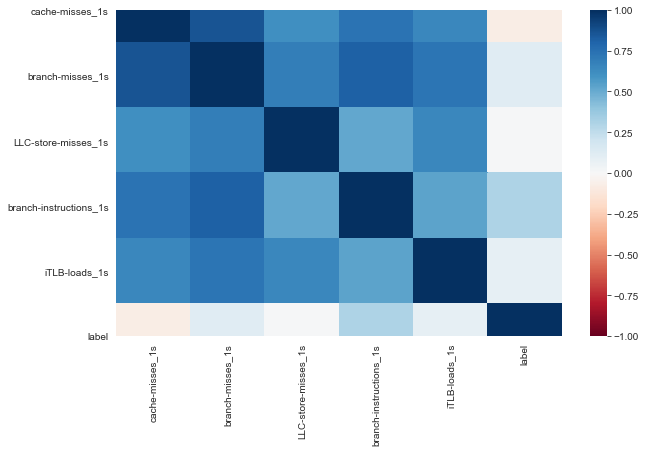

```python
# Let's use Seaborn to do the heatmap
plt.figure(figsize=(10, 6))
sns.heatmap(corr, vmin=-1, vmax=1, center=0, annot=False, cmap= 'RdBu')
```

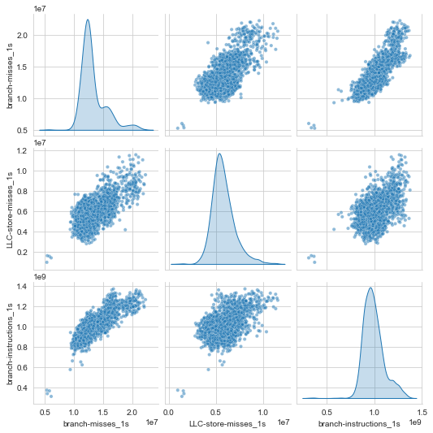

```python
sns.pairplot(data=data,
             # Use kde for the diagonal subplots
             vars=['branch-misses_1s', 'LLC-store-misses_1s', 'branch-instructions_1s'],
             diag_kind='kde',
             plot_kws=dict(
                 size=.5,
                 alpha=.5,
             ))
```

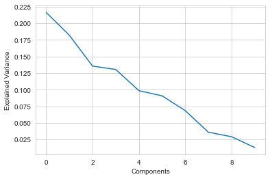

```python
import pandas as pd
import numpy as np
from sklearn.decomposition import PCA
import matplotlib.pyplot as plt

df = pd.DataFrame(data=np.random.normal(0, 1, (20, 10)))

df_normalized=(df - df.mean()) / df.std()
pca = PCA(n_components=df.shape[1])
pca.fit(df_normalized)

loadings = pd.DataFrame(pca.components_.T,
columns=['PC%s' % _ for _ in range(len(df_normalized.columns))],
index=df.columns)

plt.plot(pca.explained_variance_ratio_)
plt.ylabel('Explained Variance')
plt.xlabel('Components')
plt.show()
```